# Single cell RNA-seq Workshop: normalization, dimension reduction and clustering

## Single-cell RNAseq Workshop

Normalization, dimension reduction and clustering

Oct 21, 2026

## Purpose of each step

| Step | Purpose |
| --- | --- |
| Normalize | Correct library size |
| PCA | Summarize gene variation to fewer dimensions |
| Cluster | Proxy for cell types or states |
| UMAP | Condense expression profiles to a 2D view |

## Begin with raw counts after QC

```r
library(Seurat)
set.seed(42)

seu <- readRDS("raw_seu.Rds")

# sort the levels by sample number
seu$orig.ident <- forcats::fct_relevel(seu$orig.ident, function(x) stringr::str_sort(x, numeric=TRUE))

drop <- seu$celltype.mapped %in% c("stripped", "Doublet")
seu <- seu[, !drop]
seu
```

```
An object of class Seurat
29453 features across 19426 samples within 1 assay
Active assay: RNA (29453 features, 0 variable features)
 1 layer present: counts
```

```r
# we 'split' the Seurat object to tell Seurat the cells are derived from different samples
seu[["RNA"]] <- split(seu[["RNA"]], f = seu$orig.ident)
seu
```

```
An object of class Seurat
29453 features across 19426 samples within 1 assay
Active assay: RNA (29453 features, 0 variable features)
 6 layers present: counts.sample5, counts.sample6, counts.sample7, counts.sample8, counts.sample9, counts.sample10
```

Rows represent genes; columns represent cells. Counts are nonnegative and often sparse.

RNA assay: `counts` layer

## Normalization puts cells on a comparable scale

### Problem

One cell has 2,000 detected molecules; another has 10,000. Larger totals can dominate raw comparisons.

### LogNormalize

Divide each gene count by that cell’s total, multiply by 10,000, then apply `log1p`.

`log1p(count / cell total × 10,000)`

## Seurat object structure

```
Seurat object
├── assays slot
│   ├── RNA assay
│   │   └── layers slot
│   │       ├── counts       Raw counts
│   │       ├── data         Normalized expression
│   │       └── scale.data   Scaled expression
├── meta.data slot          Cell annotations and QC metrics
├── reductions slot         PCA, UMAP, etc.
├── graphs slot             Cell–cell graphs (e.g., NN, SNN) for clustering
└── other slots
```

## Run log normalization

```r
DefaultAssay(seu) <- "RNA"
seu <- NormalizeData(
  seu,
  normalization.method = "LogNormalize",
  scale.factor = 10000
)
```

Seurat v5: `seu[["RNA"]]$data`

## Normalization and scaling solve different problems

### NormalizeData()

Within each cell: correct for differences in total counts and log transform.

### ScaleData()

Within each gene: center values across cells and scale variance before PCA so that highly expressed genes do not dominate.

Scaling never replaces normalization in this standard workflow.

## Focus PCA on informative genes

```r
seu <- FindVariableFeatures(
  seu, selection.method = "vst", nfeatures = 2000
)
VariableFeaturePlot(seu)
```

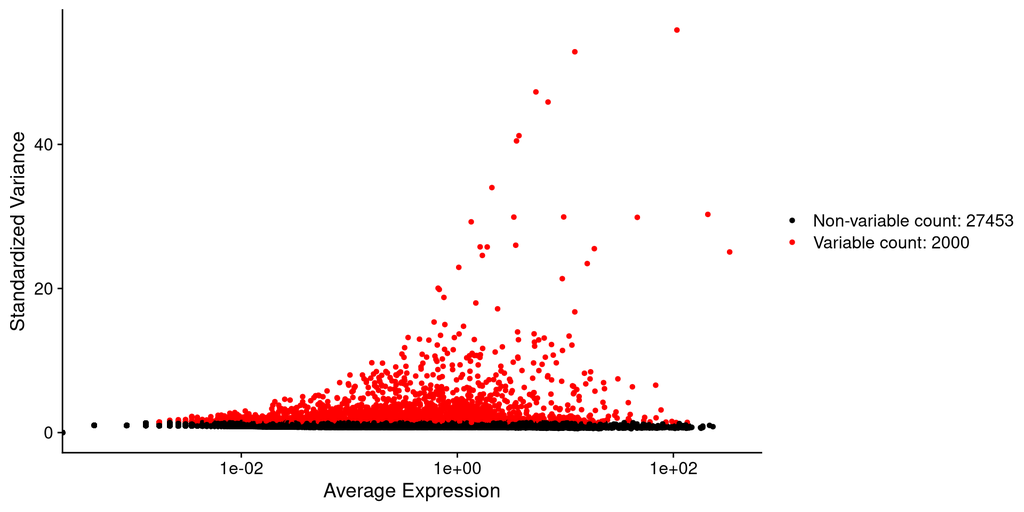

Highly variable features vary more than expected at their average expression.

## Scale variable genes, then run PCA

```r
seu <- ScaleData(seu)

seu <- RunPCA(seu, npcs = 50)
```

Output: `seu[["pca"]]`

## A PC is a weighted pattern of gene expression

### Gene loadings

Which genes contribute to a component? Positive and negative signs describe opposite directions.

### Cell scores

Where does each cell fall along that expression pattern?

PCs can correspond to genetic programs of different cell types.

## Inspect the PCs before choosing dimensions

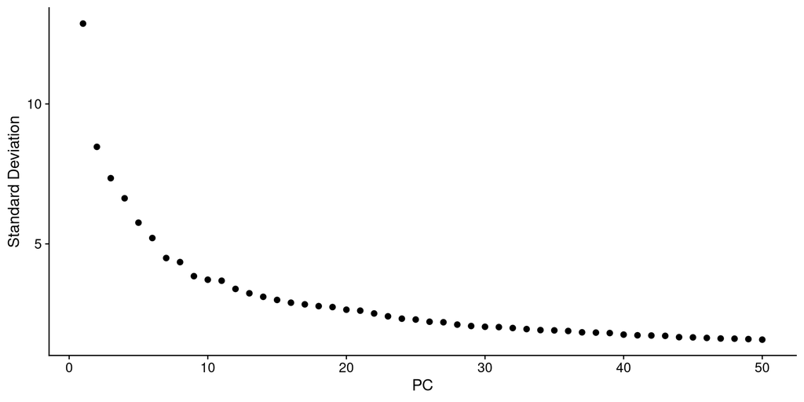

```r
ElbowPlot(seu, ndims = 50)
```

```r
print(seu[["pca"]], dims = 1:5, nfeatures = 5)
```

```
PC_ 1
Positive:  Hbb-bh1, Hba-x, Cited4, Gypa, Hba-a1
Negative:  Tmsb10, Marcksl1, Serpinh1, Tuba1a, Tceal9
PC_ 2
Positive:  Crabp2, Set, Ptn, Psip1, Cdca7
Negative:  Acta2, Cryab, Tagln, Tnni1, Tnnt2
PC_ 3
Positive:  Ttn, Tnnc1, Myl7, Myl4, Actc1
Negative:  Esam, Cldn5, Plvap, Rasip1, Icam2
PC_ 4
Positive:  Hand1, Col1a1, Dlk1, Col1a2, Pmp22
Negative:  Esam, Rasip1, Cldn5, Icam2, Cdh5
PC_ 5
Positive:  Twist1, Bcat1, Cdh2, Sfrp1, Lef1
Negative:  Cldn6, Epcam, Cldn7, Spint2, Prss8
```

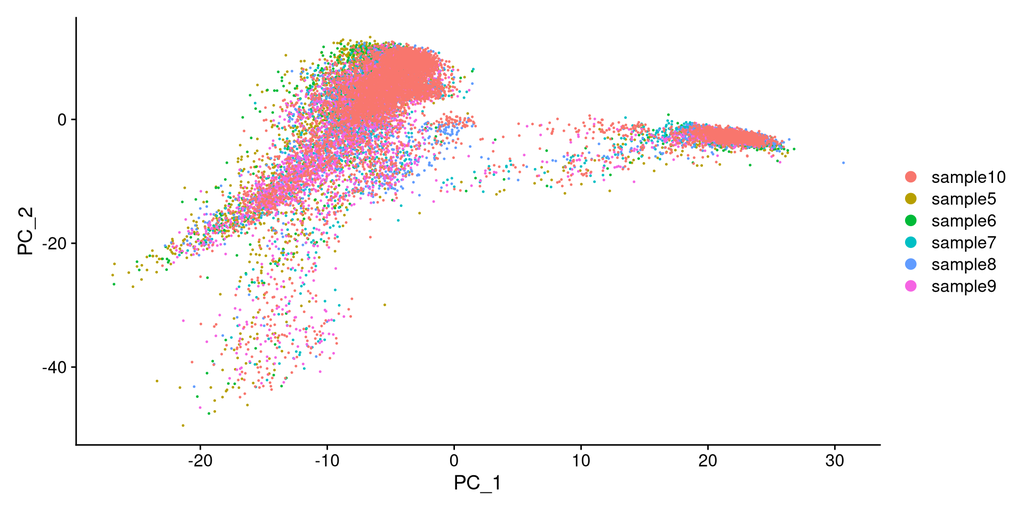

```r
DimPlot(seu, reduction = "pca")
```

Look for diminishing variance and inspect the genes driving each PC.

## Choose PCs for downstream work

### Example choice: PCs 1–30

Use a contiguous range for the tutorial. Record the selected dimension count so results are reproducible.

### Sensitivity check

Compare reasonable ranges such as 1–15 and 1–30; inspect whether major groups persist.

Our example: `dims = 1:30`

## Clustering starts with neighbors in PCA space

### FindNeighbors()

Cells near each other in the selected PC dimensions become neighbors.

### Shared-neighbor graph

Edges receive stronger support when two cells share many neighbors.

```r
n_pcs <- 30
seu <- FindNeighbors(seu, dims = 1:n_pcs)
```

## Graph communities become cluster labels

- Adjusting the resolution affects the number of clusters returned.
- Multiple cluster resolutions can be specified in the same command.

```r
seu <- FindClusters(seu, resolution = c(0.3, 0.5, 1), random.seed = 42)
```

```
Modularity Optimizer version 1.3.0 by Ludo Waltman and Nees Jan van Eck

Number of nodes: 19426
Number of edges: 673846

Running Louvain algorithm...
Maximum modularity in 10 random starts: 0.9537
Number of communities: 18
Elapsed time: 2 seconds
Number of nodes: 19426
Number of edges: 673846

Running Louvain algorithm...
Maximum modularity in 10 random starts: 0.9380
Number of communities: 23
Elapsed time: 1 seconds
Number of nodes: 19426
Number of edges: 673846

Running Louvain algorithm...
Maximum modularity in 10 random starts: 0.9124
Number of communities: 31
Elapsed time: 2 seconds
```

```r
DimPlot(seu, reduction = "pca", group.by = "seurat_clusters")
```

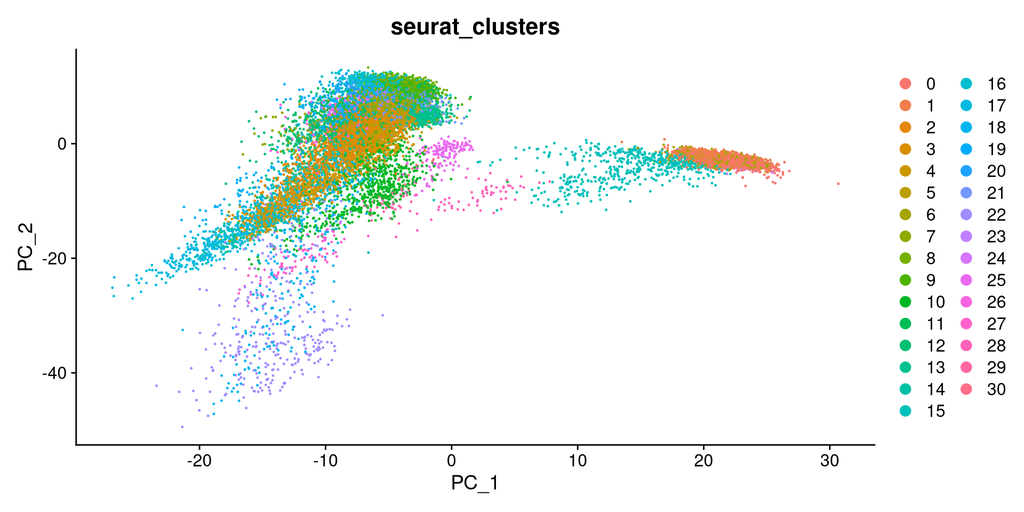

Higher resolution generally returns more communities; labels are arbitrary IDs.

## UMAP turns local neighbors into a 2D view

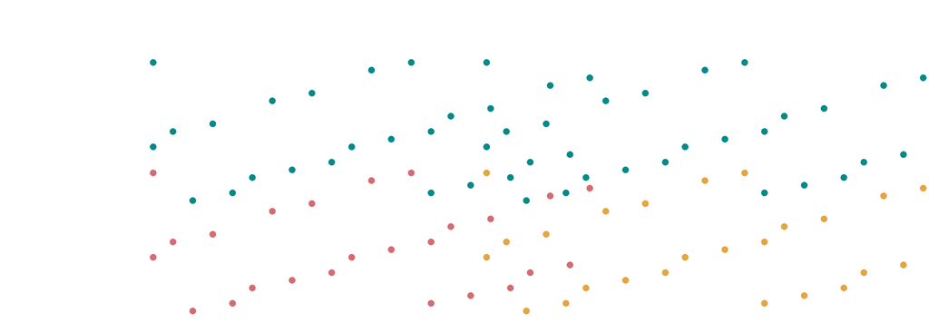

Schematic embedding

Nearby points often reflect similar profiles in the chosen PCA space.

## Compute and display UMAP

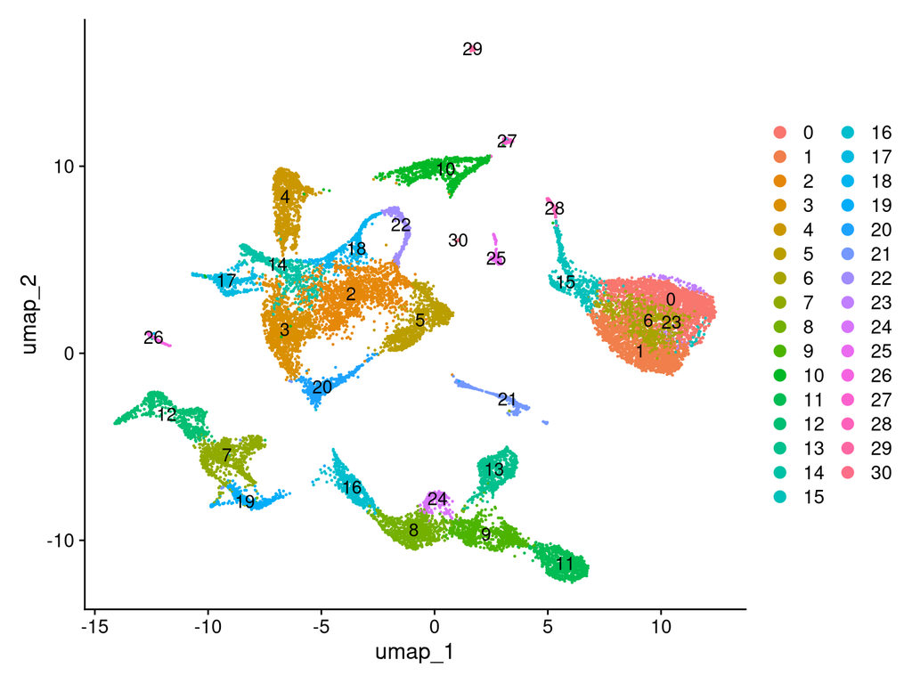

```r
seu <- RunUMAP(seu, dims = 1:n_pcs, seed.use = 42)
DimPlot(seu, reduction = "umap", label = TRUE)
```

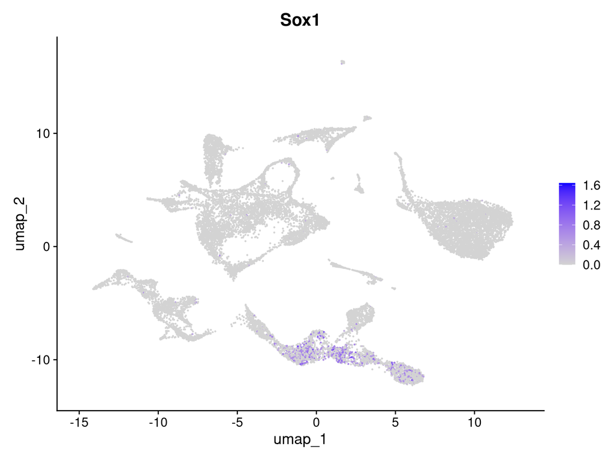

```r
FeaturePlot(seu, features = "Sox1")
```

Clusters were computed from the neighbor graph

## UMAP pictures can change without changing biology

### Trust local patterns cautiously

Cells close together tend to have related profiles. Density and relative island spacing can shift.

### Verify with expression

Use marker genes, QC metrics, sample labels, and known biology before naming a group.

A cluster boundary on UMAP displays graph labels; clustering uses the neighbor graph.

## Batch correction adds a separate analysis step

### Normalization

Account for count depth within the data.

### Integration across batches

Align shared cell populations across technical groups before building a neighbor graph.

Shared cell types should align while meaningful biological differences remain.

## Seurat v5 splits RNA layers by technical group

`orig.ident` identifies the sample of a given cell came from.

## RPCA integration returns a corrected embedding

```r
# "For certain functions, each worker needs access to certain global variables. If these are larger than the default limit, you will see this error. To get around this, you can set options(future.globals.maxSize = X), where X is the maximum allowed size in bytes."
options(future.globals.maxSize = 10000 * 1024^2) # 10 GB

seu <- IntegrateLayers(
  object = seu, method = RPCAIntegration,
  orig.reduction = "pca", new.reduction = "integrated.rpca",
  verbose = FALSE
)
```

The corrected reduction supplies coordinates for the next steps

## Neighbors and UMAP use the integrated reduction

```r
seu <- FindNeighbors(
  seu, reduction = "integrated.rpca", dims = 1:n_pcs
)
seu <- FindClusters(seu, resolution = 0.5, random.seed = 42)
```

```
Modularity Optimizer version 1.3.0 by Ludo Waltman and Nees Jan van Eck

Number of nodes: 19426
Number of edges: 744977

Running Louvain algorithm...
Maximum modularity in 10 random starts: 0.9434
Number of communities: 27
Elapsed time: 2 seconds
```

```r
seu <- RunUMAP(
  seu,
  reduction = "integrated.rpca",
  dims = 1:n_pcs,
  reduction.name = "umap.integrated",
  seed.use = 42
)
```

Both neighbors and UMAP use the same corrected reduction

## Batch mixing and biological signal both matter

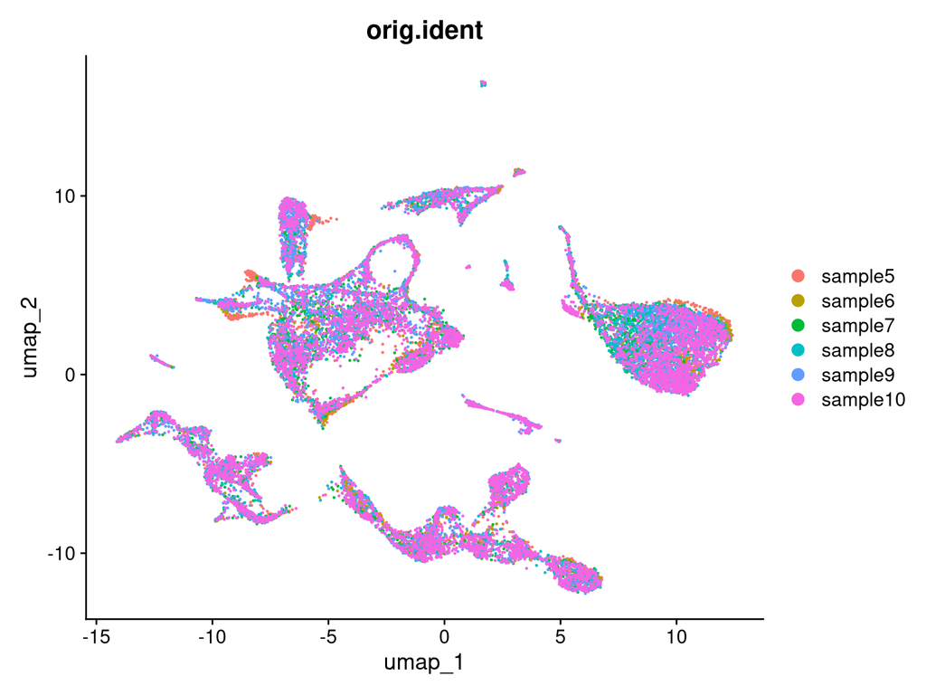

```r
DimPlot(seu, reduction = "umap", group.by = "orig.ident")
```

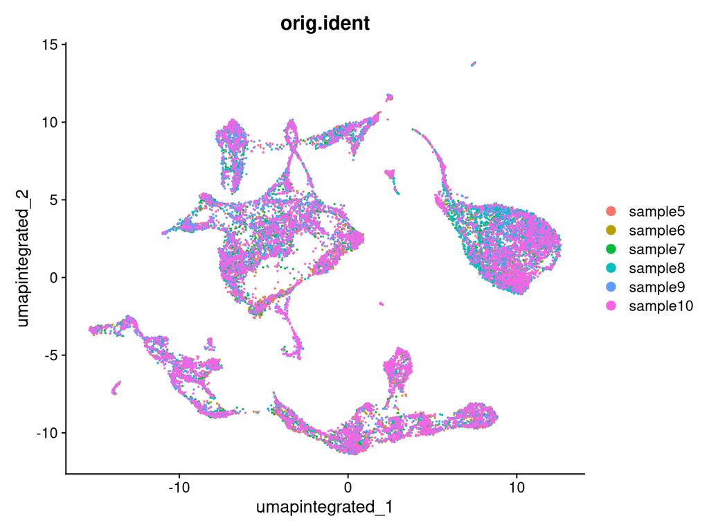

```r
DimPlot(seu, reduction = "umap.integrated", group.by = "orig.ident")
```

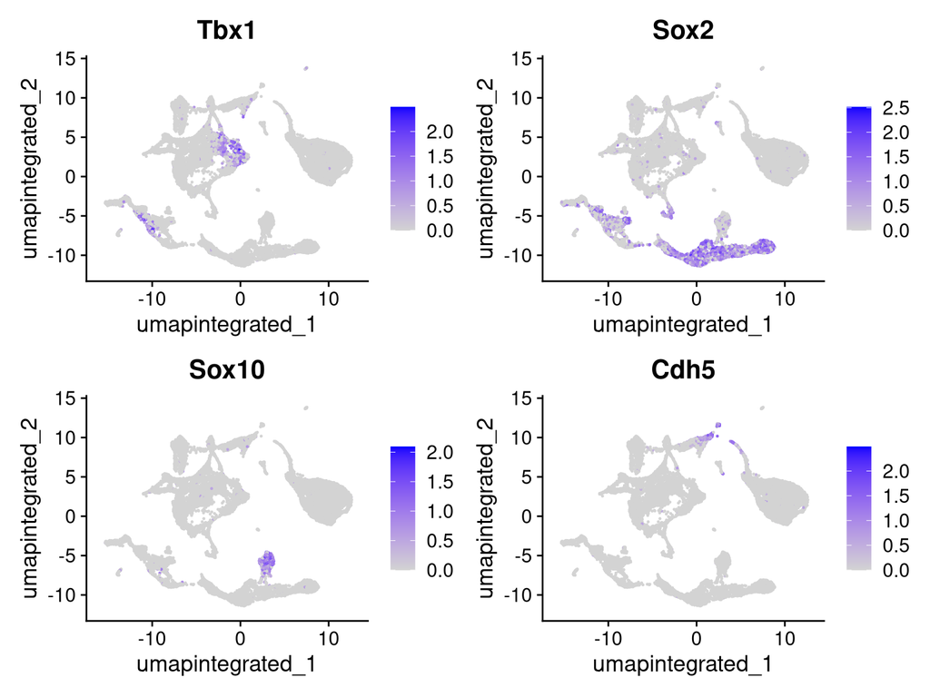

```r
FeaturePlot(seu,
            reduction = "umap.integrated",
            features = c("Tbx1", "Sox2", "Sox10", "Cdh5"))
```

Compare mixing within shared cell types and preservation of markers.

Condition comparisons still need sample identities and biological replicates.

## Check correction without erasing biology

### Batch composition

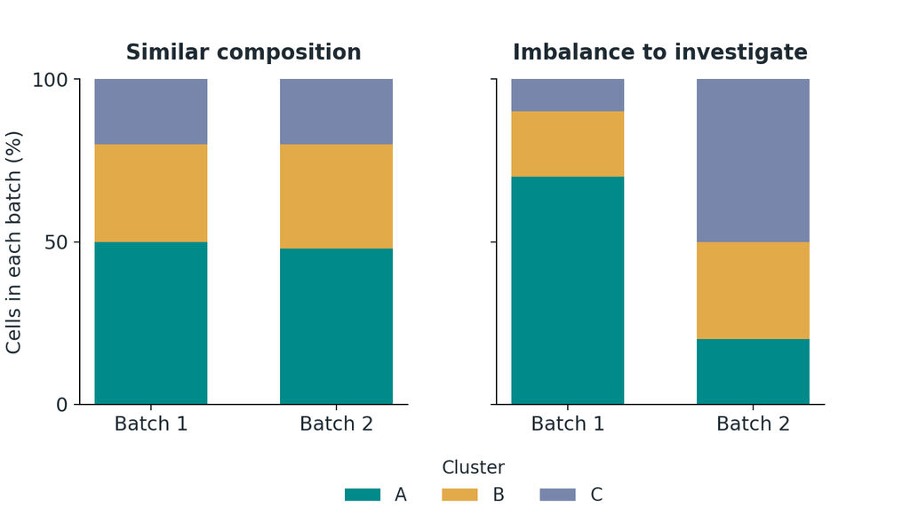

Compare cluster percentages across batches. Unequal composition can reflect incomplete correction or real biology; technical replicates should be more similar.

### Within-batch structure

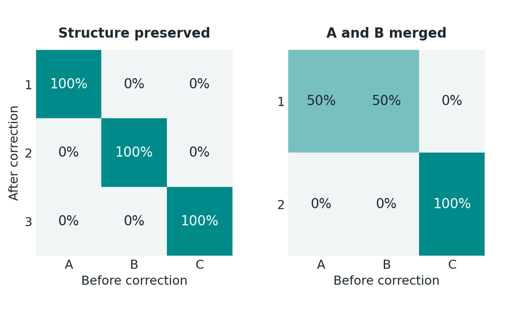

Compare labels within each batch before and after integration. Each corrected cluster should map mainly to one original cluster; inspect nesting and ARI.

Good mixing must preserve biological structure. Splitting a cluster may reveal finer structure.

Schematic examples, not experimental results. Source: [OSCA: Correction diagnostics (Bioconductor 3.21)](https://bioconductor.org/books/3.21/OSCA.multisample/correction-diagnostics.html)

## Save Seurat object for next workshop

```r
saveRDS(seu, "day2_session2_seu.rds")
```

## A complete, runnable Seurat sequence

```r
library(Seurat)
# seu = QC-filtered Seurat object
DefaultAssay(seu) <- "RNA"
seu <- NormalizeData(seu)
seu <- FindVariableFeatures(seu, nfeatures = 2000)
seu <- ScaleData(seu)
seu <- RunPCA(seu, npcs = 50)

seu <- FindNeighbors(seu, dims = 1:30)
seu <- FindClusters(seu, resolution = 0.5)
seu <- RunUMAP(seu, dims = 1:30, seed.use = 42)
```

## Parameters to choose and record

| Step | What to record |
| --- | --- |
| Preprocessing | LogNormalize or SCT v2 |
| PCA | Selected genes and number of PCs |
| Integration | Technical grouping, method |
| Clustering | PC range, resolution, seed |
| UMAP | Reduction, PC range, seed and settings |

## Takeaways

1. LogNormalize adjusts cell totals.
2. PCA captures major gene expression patterns.
3. Integration aligns shared populations across batches.
4. Clustering groups cells on a neighbor graph.
5. UMAP displays relationships in two dimensions.

## Bonus: Try other integration methods

- Note how these are stored as additional reduction objects.
- These can each be used for clustering and UMAP by specifying the relevant reduction in the ‘reduction’ arguments of FindNeighbors() and RunUMAP().

```r
seu <- IntegrateLayers(object = seu,
                        method = HarmonyIntegration,
                        orig.reduction = "pca",
                        new.reduction = "integrated.harmony",
                        verbose = FALSE)

# need to load this package to get FastMNNIntegration
library(SeuratWrappers)
seu <- IntegrateLayers(object = seu,
                        method = FastMNNIntegration,
                        new.reduction = "integrated.mnn",
                        verbose = FALSE)

seu@reductions
```

```
$pca
A dimensional reduction object with key PC_
 Number of dimensions: 50
 Number of cells: 19426
 Projected dimensional reduction calculated:  FALSE
 Jackstraw run: FALSE
 Computed using assay: RNA

$umap
A dimensional reduction object with key umap_
 Number of dimensions: 2
 Number of cells: 19426
 Projected dimensional reduction calculated:  FALSE
 Jackstraw run: FALSE
 Computed using assay: RNA

$integrated.rpca
A dimensional reduction object with key integratedrpca_
 Number of dimensions: 50
 Number of cells: 19426
 Projected dimensional reduction calculated:  FALSE
 Jackstraw run: FALSE
 Computed using assay: RNA

$umap.integrated
A dimensional reduction object with key umapintegrated_
 Number of dimensions: 2
 Number of cells: 19426
 Projected dimensional reduction calculated:  FALSE
 Jackstraw run: FALSE
 Computed using assay: RNA

$integrated.harmony
A dimensional reduction object with key harmony_
 Number of dimensions: 50
 Number of cells: 19426
 Projected dimensional reduction calculated:  FALSE
 Jackstraw run: FALSE
 Computed using assay: RNA

$integrated.mnn
A dimensional reduction object with key mnn_
 Number of dimensions: 50
 Number of cells: 19426
 Projected dimensional reduction calculated:  FALSE
 Jackstraw run: FALSE
 Computed using assay: RNA
```

## Bonus: Try scTransform instead of NormalizeData(), FindVariableFeatures(), and ScaleData()

SCTransform models the raw UMI counts

### Gene-wise count model

Fits regularized negative-binomial models to account for sequencing depth.

### Variance-stabilized residuals

Pearson residuals describe expression above or below each gene’s fitted expectation.

Seurat v5 uses SCT v2 by default

## Bonus: Try scTransform instead of NormalizeData(), FindVariableFeatures(), and ScaleData()

First, make a new copy of the Seurat object with just the raw counts and meta data.

```r
# Rejoin the RNA layers so that GetAssayData can work; also needed for downstream analyses like DE analysis.
seu <- JoinLayers(seu, assay = "RNA")

counts <- GetAssayData(seu, assay = "RNA", layer = "counts")

seu_sct <- CreateSeuratObject(
  counts = counts,
  meta.data = seu[[]][colnames(counts), , drop = FALSE],
  assay = "RNA"
)

seu_sct[["RNA"]] <- split(seu_sct[["RNA"]], f = seu_sct$orig.ident)
```

## Bonus: Try scTransform instead of NormalizeData(), FindVariableFeatures(), and ScaleData()

- seu[[“SCT”]]$scale.data: Contains the Pearson residuals used directly as input for PCA.
- seu[[“SCT”]]$counts: Contains the ‘corrected’ UMI counts (expected counts if all cells had uniform sequencing depth).
- seu[[“SCT”]]$data: Contains the log-normalized version of the corrected counts for visualization (e.g., FeaturePlots, ViolinPlots).

```r
seu_sct <- SCTransform(seu_sct)
seu_sct # note new SCT assay is now the active assay
```

```
An object of class Seurat
46614 features across 19426 samples within 2 assays
Active assay: SCT (17161 features, 3000 variable features)
 3 layers present: counts, data, scale.data
 1 other assay present: RNA
```

```r
seu_sct <- RunPCA(seu_sct, npcs = 30)
seu_sct <- IntegrateLayers(object = seu_sct, method = RPCAIntegration, normalization.method = "SCT", new.reduction = "rpca.sct")
seu_sct <- FindNeighbors(seu_sct, dims = 1:30, reduction = "rpca.sct")
seu_sct <- FindClusters(seu_sct, resolution = 2)
```

```
Modularity Optimizer version 1.3.0 by Ludo Waltman and Nees Jan van Eck

Number of nodes: 19426
Number of edges: 669631

Running Louvain algorithm...
Maximum modularity in 10 random starts: 0.8903
Number of communities: 51
Elapsed time: 1 seconds
```